# Final Project

## Welcome

Welcome to my final project for Biol3100. This is where I will be showing what I have learned this semester. For this final project I will be taking a data set and walking you through some of the cleaning, plotting and analysis of this data.

## Objective

My objective in this project is to be able to use plotting to display where all of the algal blooms in California are located. I will be making an interactive map that labels the kind of water body type and the location of the bloom. Finally I will be analyzing what “water body type” bloom is most common.

## Cleaning the data

For this project I spent the majority of my time cleaning and sorting through the data. In the Column of “water_body_type” there was over 40 different names used to describe bloom locations so I needed to sort through all the names until there were was only five left: river, lake, reservoir, bay and pond. Below displays the evidence of that cleaning by displaying all of the unique names within the “water body type” column.

```
## [1] "river"     "lake"      "bay"       "reservoir" "pond"
```

## Bloom Location

Here is a very simple plot that will show the location of the Algal blooms along the state of California. The plot uses the exact latitudinal and longitudinal locations of these algal blooms and makes a graph that is in a vague shape of California.

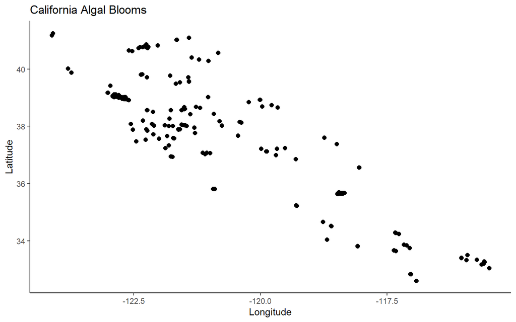

## Types of Blooms

For this graph I used the Leaflet package to make an interactive graph that shows the location and type of bloom. For added effect I have color coded the types of blooms and I have added markers that will also label what type of bloom is in that location.

[interactive chart not shown]

## Bloom Occurance

This final plot uses a facet wrap to visualize the occurrence of algal blooms in different water body types. We can see from this graph that most algal blooms occur in lakes. This makes sense because according to what we know about algal blooms they happen most often in areas that have stagnant water, abundant light, and high levels of nutrients such as nitrogen and phosphorous.

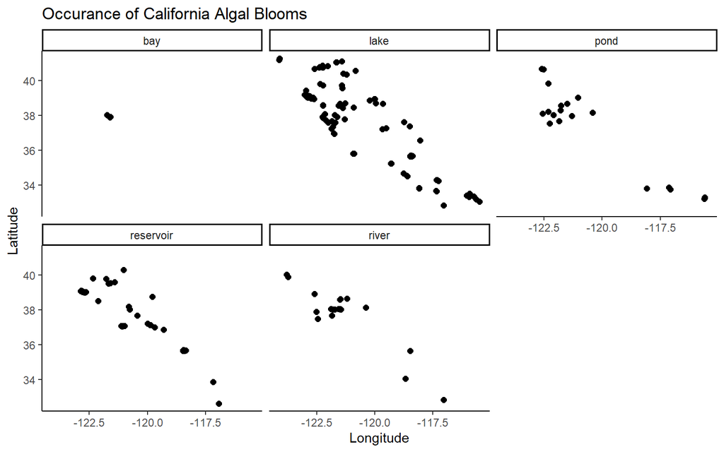

## Conclusion

This data set did not provide enough numerical data to perform any kind of modeling or predictions. If there had been data on where there are no blooms present I could have compared the data been bloom locations and non-bloom locations. I hope to be able to this in the future.

With the data that was available I was able to successfully make graphs that showed bloom locations and what kind of bloom were present. I was also able to make an interactive map that made it easier to distinguish where each water body type was located, and lastly I was able to make a graph that showed which water body type had the most blooms.